# Apartado 9.7 Ejercicio 8

Daniel Ceballos Monsalve

Andrés Felipe Mejía Quintero

Doris Steffania Obando Gonzalez

Librerias a utilizar

```r
library(ISLR)
library(e1071)
library(ggplot2)
```

## Ejercicio 8

Este problema involucra el conjunto de datos OJ que es parte del paquete ISLR

### Enunciado a:

Cree un conjunto de entrenamiento que contenga una muestra aleatoria de 800 observaciones y un conjunto de prueba que contenga las observaciones restantes.

```r
set.seed(700)
train = sample(nrow(OJ), 800)
OJ_Train = OJ[train, ]
OJ_Test = OJ[-train, ]
```

### Enunciado b:

Ajuste un clasificador de vector de soporte a los datos de entrenamiento usando costo = 0.01, con Compra como respuesta y las otras variables como predictores. Utilice la función de summary() para producir estadísticas de resumen y describir los resultados obtenidos.

```r
SVM_Lineal = svm(Purchase ~ ., kernel = "linear", data = OJ_Train, cost = 0.01)
summary(SVM_Lineal)
```

```
##
## Call:
## svm(formula = Purchase ~ ., data = OJ_Train, kernel = "linear", cost = 0.01)
##
##
## Parameters:
##    SVM-Type:  C-classification
##  SVM-Kernel:  linear
##        cost:  0.01
##
## Number of Support Vectors:  444
##
##  ( 223 221 )
##
##
## Number of Classes:  2
##
## Levels:
##  CH MM
```

### Enunciado c:

¿Cuáles son las tasas de error de entrenamiento y prueba?

```r
Predic_Train = predict(SVM_Lineal, OJ_Train)
table(predicho = Predic_Train, real = OJ_Train$Purchase)
```

```
##         real
## predicho  CH  MM
##       CH 427  73
##       MM  57 243
```

```r
Error_Train = round(mean(Predic_Train != OJ_Train$Purchase),4)
paste("El error de entrenamiento es de:", Error_Train)
```

```
## [1] "El error de entrenamiento es de: 0.1625"
```

```r
Predic_Test = predict(SVM_Lineal, OJ_Test)
table(predicho = Predic_Test, OJ_Test$Purchase)
```

```
##
## predicho  CH  MM
##       CH 153  31
##       MM  16  70
```

```r
Error_Test = round(mean(Predic_Test != OJ_Test$Purchase),4)
paste("El error con los datos de validación es de: :", Error_Test)
```

```
## [1] "El error con los datos de validación es de: : 0.1741"
```

### Enunciado d:

Utilice la función tune () para seleccionar un costo óptimo. Considere valores en el rango de 0.01 a 10.

```r
set.seed(200)
Model_Tuning = tune(svm, Purchase ~ ., data = OJ_Train, kernel = "linear",
                    ranges = list(cost = 10^seq(-2, 1, by = 0.25)))
summary(Model_Tuning)
```

```
##
## Parameter tuning of 'svm':
##
## - sampling method: 10-fold cross validation
##
## - best parameters:
##      cost
##  5.623413
##
## - best performance: 0.1625
##
## - Detailed performance results:
##           cost   error dispersion
## 1   0.01000000 0.17375 0.02239947
## 2   0.01778279 0.17000 0.02713137
## 3   0.03162278 0.16750 0.02371708
## 4   0.05623413 0.17125 0.02949223
## 5   0.10000000 0.17375 0.03143004
## 6   0.17782794 0.17375 0.03143004
## 7   0.31622777 0.17500 0.02946278
## 8   0.56234133 0.17625 0.03030516
## 9   1.00000000 0.17375 0.03458584
## 10  1.77827941 0.17250 0.03374743
## 11  3.16227766 0.16500 0.03216710
## 12  5.62341325 0.16250 0.03280837
## 13 10.00000000 0.16375 0.03197764
```

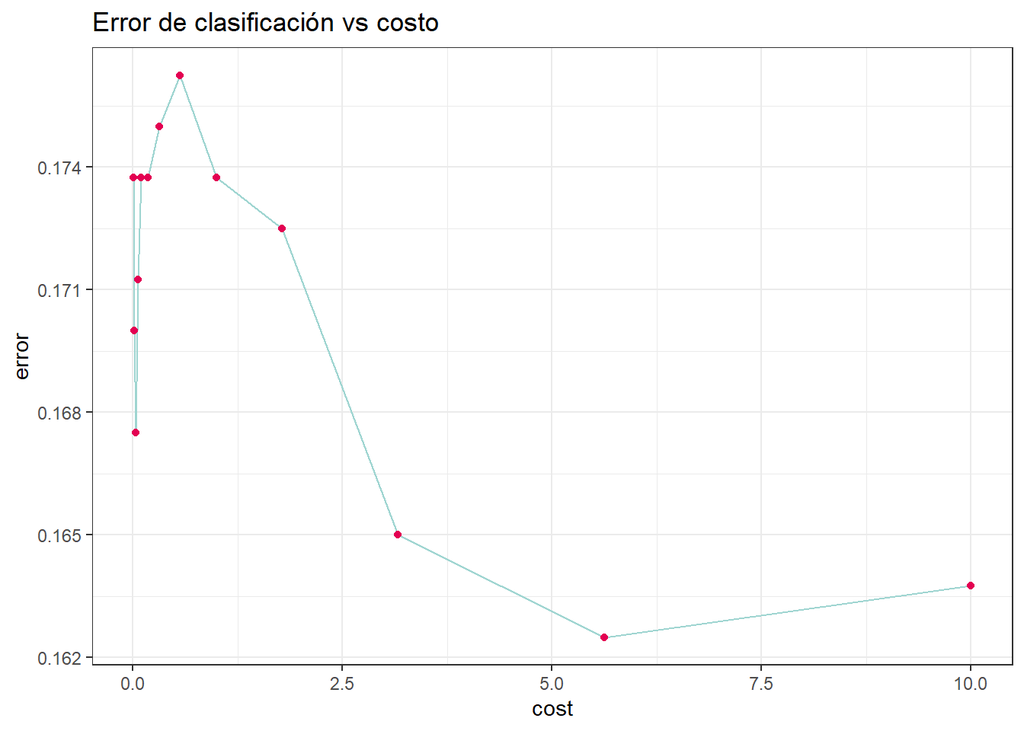

```r
ggplot(data = Model_Tuning$performances, aes(x = cost, y = error)) +
  geom_line(color = "#9FD5D1") +
  geom_point(color = "#E30052") +
  labs(title = "Error de clasificación vs costo") +
  theme(plot.title = element_text(hjust = 0.5)) +
  theme_bw() + theme(legend.position = "none")
```

### Enunciado e:

Calcule las tasas de error de entrenamiento y prueba utilizando este nuevo valor de costo.

```r
Model_Tuning$best.model
```

```
##
## Call:
## best.tune(method = svm, train.x = Purchase ~ ., data = OJ_Train,
##     ranges = list(cost = 10^seq(-2, 1, by = 0.25)), kernel = "linear")
##
##
## Parameters:
##    SVM-Type:  C-classification
##  SVM-Kernel:  linear
##        cost:  5.623413
##
## Number of Support Vectors:  331
```

```r
Mejor_SVM_Lineal = svm(Purchase ~ ., kernel = "linear", data = OJ_Train,
                       cost =Model_Tuning$best.parameters$cost)
Predic_Train = predict(Mejor_SVM_Lineal, OJ_Train)
table(predicho = Predic_Train, real = OJ_Train$Purchase)
```

```
##         real
## predicho  CH  MM
##       CH 429  69
##       MM  55 247
```

```r
Error_Train = round(mean(Predic_Train != OJ_Train$Purchase),4)
paste("El error de entrenamiento con el mejor SVM lineal es de ", Error_Train)
```

```
## [1] "El error de entrenamiento con el mejor SVM lineal es de  0.155"
```

```r
Predic_Test = predict(Mejor_SVM_Lineal, OJ_Test)
table(predicho = Predic_Test, real = OJ_Test$Purchase)
```

```
##         real
## predicho  CH  MM
##       CH 151  30
##       MM  18  71
```

```r
Error_Test = round(mean(Predic_Test != OJ_Test$Purchase),4)
paste("El error con los datos de validación con el mejor SVM lineal es de:", Error_Test)
```

```
## [1] "El error con los datos de validación con el mejor SVM lineal es de: 0.1778"
```

### Enunciado f:

Repita las partes (b) a (e) usando una máquina de vectores de soporte con un núcleo radial. Utilice el valor predeterminado para gamma.

```r
set.seed(600)
SVM_Radial = svm(Purchase ~ ., data = OJ_Train, kernel = "radial")
summary(SVM_Radial)
```

```
##
## Call:
## svm(formula = Purchase ~ ., data = OJ_Train, kernel = "radial")
##
##
## Parameters:
##    SVM-Type:  C-classification
##  SVM-Kernel:  radial
##        cost:  1
##
## Number of Support Vectors:  368
##
##  ( 184 184 )
##
##
## Number of Classes:  2
##
## Levels:
##  CH MM
```

```r
Predic_Train = predict(SVM_Radial, OJ_Train)
table(predicho = Predic_Train, real = OJ_Train$Purchase)
```

```
##         real
## predicho  CH  MM
##       CH 442  77
##       MM  42 239
```

```r
Error_Train = round(mean(Predic_Train != OJ_Train$Purchase),4)
paste("El error de entrenamiento es de: :", Error_Train)
```

```
## [1] "El error de entrenamiento es de: : 0.1488"
```

```r
Predic_Test = predict(SVM_Radial, OJ_Test)
table(predicho = Predic_Test, real = OJ_Test$Purchase)
```

```
##         real
## predicho  CH  MM
##       CH 154  36
##       MM  15  65
```

```r
Error_Test = round(mean(Predic_Test != OJ_Test$Purchase),4)
paste("El error con los datos de validación es de: :", Error_Test)
```

```
## [1] "El error con los datos de validación es de: : 0.1889"
```

```r
set.seed(400)
Tuning_Radial = tune(svm, Purchase ~ ., data = OJ_Train, kernel = "radial",
                     ranges = list(cost = 10^seq(-2, 1, by = 0.25)))
summary(Tuning_Radial)
```

```
##
## Parameter tuning of 'svm':
##
## - sampling method: 10-fold cross validation
##
## - best parameters:
##       cost
##  0.5623413
##
## - best performance: 0.16875
##
## - Detailed performance results:
##           cost   error dispersion
## 1   0.01000000 0.39500 0.04758034
## 2   0.01778279 0.39500 0.04758034
## 3   0.03162278 0.33875 0.07440738
## 4   0.05623413 0.20500 0.03872983
## 5   0.10000000 0.17875 0.04528076
## 6   0.17782794 0.17250 0.03763863
## 7   0.31622777 0.17000 0.03593976
## 8   0.56234133 0.16875 0.04050463
## 9   1.00000000 0.16875 0.04259385
## 10  1.77827941 0.17000 0.04377975
## 11  3.16227766 0.17125 0.04641674
## 12  5.62341325 0.17125 0.03821086
## 13 10.00000000 0.17500 0.03864008
```

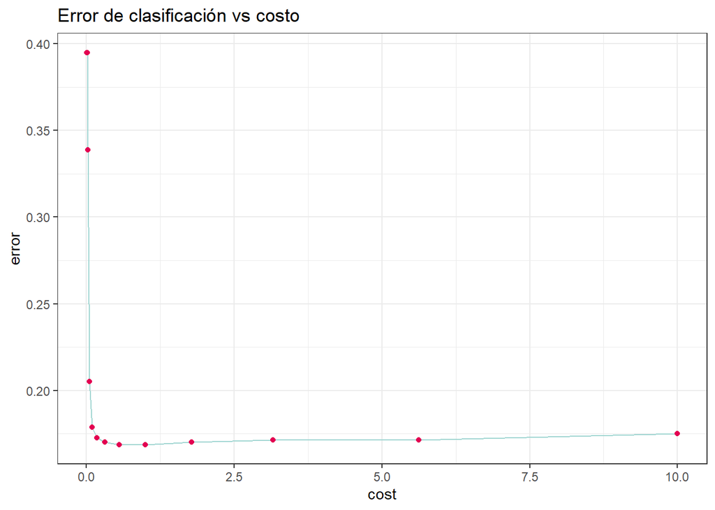

```r
ggplot(data = Tuning_Radial$performances, aes(x = cost, y = error)) +
  geom_line(color = "#9FD5D1") +
  geom_point(color = "#E30052") +
  labs(title = "Error de clasificación vs costo") +
  theme(plot.title = element_text(hjust = 0.5)) +
  theme_bw() + theme(legend.position = "none")
```

```r
Mejor_SVM_Radial = svm(Purchase ~ ., data = OJ_Train, kernel = "radial",
                       cost = Tuning_Radial$best.parameters$cost)

Predic_Train = predict(Mejor_SVM_Radial, OJ_Train)
table(predicho = Predic_Train, real = OJ_Train$Purchase)
```

```
##         real
## predicho  CH  MM
##       CH 442  79
##       MM  42 237
```

```r
Error_Train = round(mean(Predic_Train != OJ_Train$Purchase),4)
paste("El error de entrenamiento con el mejor SVM radial es de: :", Error_Train)
```

```
## [1] "El error de entrenamiento con el mejor SVM radial es de: : 0.1512"
```

```r
Predic_Test = predict(Mejor_SVM_Radial, OJ_Test)
table(predicho = Predic_Test, real = OJ_Test$Purchase)
```

```
##         real
## predicho  CH  MM
##       CH 153  37
##       MM  16  64
```

```r
Error_Test = round(mean(Predic_Test != OJ_Test$Purchase),4)
paste("El error de validación con el mejor SVM radial es de:", Error_Test)
```

```
## [1] "El error de validación con el mejor SVM radial es de: 0.1963"
```

### Enunciado g:

Repita las partes (b) a (e) usando una máquina de vectores de soporte con un núcleo polinomial. Establecer grado = 2.

```r
set.seed(1100)
SVM_Poly = svm(Purchase ~ ., data = OJ_Train, kernel = "poly", degree = 2)
summary(SVM_Poly)
```

```
##
## Call:
## svm(formula = Purchase ~ ., data = OJ_Train, kernel = "poly", degree = 2)
##
##
## Parameters:
##    SVM-Type:  C-classification
##  SVM-Kernel:  polynomial
##        cost:  1
##      degree:  2
##      coef.0:  0
##
## Number of Support Vectors:  449
##
##  ( 228 221 )
##
##
## Number of Classes:  2
##
## Levels:
##  CH MM
```

```r
Predic_Train = predict(SVM_Poly, OJ_Train)
table(predicho = Predic_Train, real = OJ_Train$Purchase)
```

```
##         real
## predicho  CH  MM
##       CH 450 107
##       MM  34 209
```

```r
Error_Train = round(mean(Predic_Train != OJ_Train$Purchase),4)
paste("El error de entrenamiento es de: :", Error_Train)
```

```
## [1] "El error de entrenamiento es de: : 0.1762"
```

```r
Predic_Test = predict(SVM_Poly, OJ_Test)
table(predicho = Predic_Test, real = OJ_Test$Purchase)
```

```
##         real
## predicho  CH  MM
##       CH 154  41
##       MM  15  60
```

```r
Error_Test = round(mean(Predic_Test != OJ_Test$Purchase),4)
paste("El error con los datos de validación es de: :", Error_Test)
```

```
## [1] "El error con los datos de validación es de: : 0.2074"
```

```r
set.seed(100)
Tuning_Poli = tune(svm, Purchase ~ ., data = OJ_Train, kernel = "poly", degree = 2,
    ranges = list(cost = 10^seq(-2, 1, by = 0.25)))
summary(Tuning_Poli)
```

```
##
## Parameter tuning of 'svm':
##
## - sampling method: 10-fold cross validation
##
## - best parameters:
##      cost
##  5.623413
##
## - best performance: 0.1775
##
## - Detailed performance results:
##           cost   error dispersion
## 1   0.01000000 0.39500 0.06952218
## 2   0.01778279 0.36875 0.05899918
## 3   0.03162278 0.35875 0.05714565
## 4   0.05623413 0.33375 0.05744865
## 5   0.10000000 0.31875 0.04611655
## 6   0.17782794 0.24750 0.04851976
## 7   0.31622777 0.20375 0.05466120
## 8   0.56234133 0.19875 0.05382908
## 9   1.00000000 0.19500 0.05439056
## 10  1.77827941 0.18000 0.06015027
## 11  3.16227766 0.18125 0.05781015
## 12  5.62341325 0.17750 0.05062114
## 13 10.00000000 0.17875 0.05138701
```

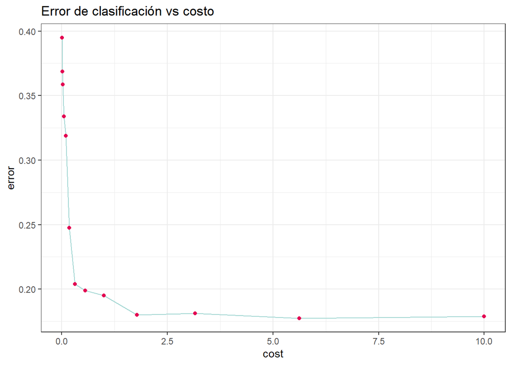

```r
ggplot(data = Tuning_Poli$performances, aes(x = cost, y = error)) +
  geom_line(color = "#9FD5D1") +
  geom_point(color = "#E30052") +
  labs(title = "Error de clasificación vs costo") +
  theme(plot.title = element_text(hjust = 0.5)) +
  theme_bw() + theme(legend.position = "none")
```

```r
Mejor_SVM_Poly = svm(Purchase ~ ., data = OJ_Train, kernel = "poly", degree = 2,
                     cost = Tuning_Poli$best.parameters$cost)

Predic_Train = predict(Mejor_SVM_Poly, OJ_Train)
table(predicho = Predic_Train, real = OJ_Train$Purchase)
```

```
##         real
## predicho  CH  MM
##       CH 446  77
##       MM  38 239
```

```r
Error_Train = round(mean(Predic_Train != OJ_Train$Purchase),4)
paste("El error de entrenamiento con el mejor SVM polinomial es de:", Error_Train)
```

```
## [1] "El error de entrenamiento con el mejor SVM polinomial es de: 0.1437"
```

```r
Predic_Test = predict(Mejor_SVM_Poly, OJ_Test)
table(predicho = Predic_Test, real = OJ_Test$Purchase)
```

```
##         real
## predicho  CH  MM
##       CH 154  37
##       MM  15  64
```

```r
Error_Test = round(mean(Predic_Test != OJ_Test$Purchase),4)
paste("El error de validación con el mejor SVM polinomial es de:", Error_Test)
```

```
## [1] "El error de validación con el mejor SVM polinomial es de: 0.1926"
```